# Abstract

Write a short (no more than 10 lines) summary of your project's topic and main goals.

This project seeks to look at the nature of languages and the changes that occur through time. In [this video](http://youtu.be/a5mZ0R3h8m0), Dr. John McWhorter discusses features of languages, and briefly mentions the divergence a language (such as Latin) undergoes in different areas over time. English, being a Germanic language, shares similarities with other Germanic languages such as German (Deutsch) and Dutch (Nederlands). Dutch is geographically situated between Germany and England, and as a result the language is in some sense halfway between the two. Other languages such as Afrikaans arose as a result of colonisation, and developed differently over time.

Through the analysis of the letter frequency of different languages, this project aims to take a look at the similarities and differences between related languages, specifically looking at Germanic languages and subsets thereof. It will do so both graphically and numerically, and reasoning will be given to account for some of the differences present.

**Warning:** after reading this project, you may experience a strong desire to do one or more of the following: [learn another language](http://www.duolingo.com), [read Beowulf](http://www.tolkienbeowulf.com/), listen to some [Icelandic](http://youtu.be/VIqUuNiCG_s) [music](http://youtu.be/kzSJBhPFTcY), [take a trip to Iceland](http://icelandaurora.com/tours/), [start riding a bike](http://stuffdutchpeoplelike.com/2012/08/15/no-1-bicycles-bikes/) or even [develop a crippling caffeine addiction](http://en.wikipedia.org/wiki/List_of_countries_by_coffee_consumption_per_capita).

# 1. Motivation

Write a detailed description of the problem and the original goal(s) of the study. Explain why you were interested in this topic and the type of insight you were hoping to get from the data.

For a long time, I've been personally interested in languages - they allow us to communicate and interact with others. However, there obviously exist language barriers between different countries, which in part is what makes mathematics so interesting - it's one of the closest things we have to a universal language, and it has set 'syntax' and rules that must be followed.

Coming from and knowing others who have a Dutch background, as well as having friends who are fluent in Afrikaans, it's often interesting to be able to understand bits and pieces of what some of those South African friends are saying, and yet still being able to see slight changes between the languages.

From this data I hope to be able to see some noticeable similarities and differences between different subsets of these Germanic languages, and get a rough idea of the divergence that occured between them over time. If possible, I also want to see if I can account for some of these differences.

# 2. The data

A clear description of the dataset(s) origin and a discussion of why it was chosen, as well as any restriction regarding the use, dissemination or modification of the data.

Note that wherever possible you should provide a link to the **unmodified, raw** data set.

To get a good idea of these different languages, I've chosen different texts from each, taken from [Project Gutenberg](http://www.gutenberg.org/). An issue with trying to analyse a language from a text is trying to find texts which represent the language - if we used the novel *Gadsby*, for example, there would be a noticeable absence of the letter 'e'. However, with the chosen data, I'm making the assumption that different authors using the same language would 'converge' on certain frequencies for each letter (given a long enough text), and small differences would be insignificant, as I'm trying to get a rough idea of differences between languages.

As the texts in a given language should (ideally) converge to certain letter frequencies, most of my choices are largely random; there's nothing in any of the following texts to suggest that it wouldn't be similar to a different text in the same language. However, for Modern English I've chosen 3 texts across different authors, locations and times to test this. Dickens' 'A Tale of Two Cities' has of course been included in this. For the North Germanic (Scandinavian) texts, there isn't a large amount of choice of texts from Project Gutenberg, so a couple of them are translations from English or another language.

As saving these .txt files directly from Project Gutenberg have names such as 'pg32865.txt', I've renamed each of them in order to be able to reference them without wondering what number corresponds with which text; beyond that, there has been no alteration of the .txt files before being processed in this notebook.

My texts are as follows:

- West Germanic
- German: Franz Kafka - *Betrachtung*
- Dutch: Hildebrand - *Camera Obscura*
  - Afrikaans: Celliers et al - *Digters uit Suid-Afrika*
- English
  - Old: *Beowulf*
  - Middle: Geoffrey Chaucer - *The Canterbury Tales*
  - Modern:
  - William Shakespeare - *Macbeth*
  - A.B. "Banjo" Paterson - *The Man From Snowy River*
  - Charles Dickens - *A Tale of Two Cities*
- North Germanic
- Insular Scandinavian
  - Icelandic: Jules Verne - *Sæfarinn*
- Continental Scandinavian
  - Norwegian: Knut Hamsun - *Markens grøde, Første del*
  - Danish: Richard Marsh - *En adelig Opdager*
  - Swedish: Johan Ludvig Runeberg - *Samlade arbeten I*

http://www.gutenberg.org/ebooks/23532 - Betrachtung

http://www.gutenberg.org/ebooks/15975 - Camera Obscura

http://www.gutenberg.org/ebooks/42302 - Digters uit Suid-Afrika

http://www.gutenberg.org/ebooks/9701 - Beowulf

http://www.gutenberg.org/ebooks/1129 - Macbeth

http://www.gutenberg.org/ebooks/213 - The Man From Snowy River

http://www.gutenberg.org/ebooks/98 - A Tale of Two Cities

http://www.gutenberg.org/ebooks/17025 - Sæfarinn

http://www.gutenberg.org/ebooks/43724 - Markens grøde, Første del

http://www.gutenberg.org/ebooks/32865 - En adelig Opdager

http://www.gutenberg.org/ebooks/13100 - Samlade arbeten I

The following is the information regarding the use of the above texts:

> This eBook is for the use of anyone anywhere at no cost and with almost no restrictions whatsoever. You may copy it, give it away or re-use it under the terms of the Project Gutenberg License included with this eBook or online at www.gutenberg.org

The full license can be found at http://www.gutenberg.org/wiki/Gutenberg:The_Project_Gutenberg_License

# 3. Data preparation

Code and comments on how the raw data is put in a usable form (i.e., how you go from the raw data set(s) to the dataframe you are using for the analysis).

**Create as many code, markdown and raw cells as needed**

From Project Gutenberg, I downloaded each text as a .txt file, encoded in UTF-8. The following code covers the python modules that need to be imported.

```python
%matplotlib inline
import matplotlib.pyplot as plt
import numpy as np
import codecs
import string
```

The following 'alphabets' cover the characters that I need within the text files.

```python
alphaEXTENDED =         u'aáäbcdðeéfghiíjklmnoóöpqrstuúüvwxyýzþæøå'
alphaEXTENDED_upper =   u'AÁÄBCDÐEÉFGHIÍJKLMNOÓÖPQRSTUÚÜVWXYÝZÞÆØÅ'
alphaBEOWULF =          u'ā$$$$$$ē$$$$ī$$$$$$ō$$$$$$$ū$$$$$ȳ$$$ǣ$$'
alphaBEOWULF_upper =    u'Ā$$$$$$Ē$$$$Ī$$$$$$Ō$$$$$$$Ū$$$$$ȳ$$$Ǣ$$'
```

The `letterProfile` function creates an empty list `letterFreq`, then cycles through the alphabets above, counting the occurence of each character and appending the sum to the `letterFreq` list.

```python
def letterProfile(f):
    '''
    Takes a file f and counts how many times each letter appears
    '''
    letterFreq = []
    for i in range(0,len(alphaEXTENDED)):
        letterFreq.append(f.count(alphaEXTENDED[i])+f.count(alphaEXTENDED_upper[i])+f.count(alphaBEOWULF[i])+f.count(alphaBEOWULF_upper[i]))
    return letterFreq
```

The `percentified` function takes the `letterFreq` list from the `letterProfile` function, and outputs a list showing the frequency that each letter appears as a percentage of the total characters.

```python
def percentified(f):
    '''
    Takes a file f and calculates the letter frequency as a percent
    '''
    return [float(item)/sum(letterProfile(f)) for item in letterProfile(f)]
```

The following `textClean` function takes the raw text file, crops out the metadata from Project Gutenberg, decodes it, and outputs the 'percentified' text. a and b for each are determined manually, by opening the .txt files in an editor such as [Notepad++](http://notepad-plus-plus.org/) and finding the lines where the text starts and ends.

```python
def textClean(f,a,b):
    '''
    Takes a string f as the title of a text file,
    writes from lines a:b in an edited file,
    decodes it as utf-8 and returns the percentified file.
    '''
    text = open('./texts/'+f+'.txt').readlines()
    open('./texts/'+f+'Edit.txt','w').writelines(text[a:b])
    edit = open('./texts/'+f+'Edit.txt').read()
    decoded = codecs.open('./texts/'+f+'Edit.txt',encoding='utf-8')
    cleaned = decoded.read()
    return percentified(cleaned)
```

Finally, the cells below takes the text files and saves the percentified lists to some variables.

```python
#Old English: Beowulf
beowulf_p = textClean('beowulf',443,3796)

#Middle English: The Canterbury Tales - Geoffrey Chaucer
canterbury_p = textClean('canterbury',1375,29557)

#English: Macbeth - William Shakespeare
macbeth_p = textClean('macbeth',220,3176)
#English: A Tale of Two Cities - Charles Dickens
taleOfTwo_p = textClean('taleOfTwo',104,15900)
#English: The Man From Snowy River - A.B. "Banjo" Paterson
snowy_p = textClean('snowy',109,3740)
```

```python
#Dutch: Camera Obscura - Nicolaas Beets (under the pseudonym Hildebrand)
camera_p = textClean('camera',476,14240)
#Afrikaans: Digters uit Suid-Afrika - Celliers, du Toit, Leipoldt, Malherbe
digters_p = textClean('digters',348,4783)
#German: Betrachtung - Franz Kafka
betrachtung_p = textClean('betrachtung',65,917)
```

```python
#Icelandic: Sæfarinn (Icelandic translation of 20000 Leagues Under the Sea) - Jules Verne
saefarinn_p = textClean('saefarinn',65,4579)
#Swedish: Samlade arbeten I - Johan Ludvig Runeberg
samlade_p = textClean('samlade',2730,25030)
#Danish: En adelig Opdager - Richard Marsh; translated by Axel Thomsen
opdager_p = textClean('opdager',149,3795)
#Norwegian: Markens grøde Første del - Knut Hamsun
markens_p = textClean('markens',90,6392)
```

# 4. Exploratory data analysis

This is the main part of the project. Include code, plots, and detailed explanation of your analysis of the data. Be sure to include enough detail so that anyone can follow and understand what you are doing.

**Create as many code, markdown and raw cells as needed**

```python
from math import sqrt

def distance(p1,p2):
    '''
    Takes 2 percentified letter profiles p1 & p2,
    and finds the Euclidean distance between them
    '''
    vector = []
    dist = 0
    for i in range(0,len(p1)):
        vector.append((p1[i] - p2[i])**2)
    dist = sqrt(sum(float(i) for i in vector))
    return dist
```

```python
def difference(p1,p2):
    '''
    Takes 2 percentified letter profiles p1 & p2,
    and finds the difference between each letter
    '''
    diff = []
    for i in range(0,len(p1)):
        diff.append((p1[i] - p2[i]))
    return diff
```

```python
def letterPlot(percents, colours, titles):
    '''
    Takes a list of percentified texts,
    a corresponding list of colours,
    and a matching list of titles.
    '''
    ind = np.arange(len(alphaEXTENDED))  # the x locations for the groups
    width = 0.8       # the width of the bars

    fig, ax = plt.subplots(figsize=(20,8))
    plt.xlim(0,len(alphaEXTENDED)+1) #widens the plot to leave some space at the end for the character å

    def autolabel(rects):
        # attach some text labels
        for rect in rects:
            height = rect.get_height()
            ax.text(rect.get_x()+rect.get_width()/2., 1.05*height, '%.2f'%float(height),
                    ha='center', va='bottom')

    rects = [None]*len(percents) #Creates sets of rectangles - one set of rectangles per text
    for i in range(0,len(percents)):
        #The width of the bars is inversely proportional to the amount of texts being compared
        rects[i] = ax.bar(width/2+ind+i*width/len(percents), percents[i],width/len(percents),color=colours[i],alpha=0.8)
        autolabel(rects[i])

    ax.set_xticks(ind+width)
    ax.set_xticklabels(alphaEXTENDED)
    ax.legend( (rects), (titles) )

    plt.show()
```

```python
def differencePlot(p1,p2,s1,s2):
    '''
    Graphs the difference in frequency for each letter between two texts.
    A positive difference means a higher frequency of the letter in p1,
    a negative difference means a higher frequency of the letter in p2.
    s1 & s2 are strings, used for the title of the graph.
    '''
    colours = 'rrrbbbbrrbbbrrbbbbbrrrbbbbbrrrbbbrrbbrrr' #vowels and y highlighted in red
    ind = np.arange(len(alphaEXTENDED))  # the x locations for the groups
    width = 0.35
    fig, ax = plt.subplots(figsize=(20,8))
    plt.title(s1 + ' - ' + s2)
    ax.set_xticks(ind+width)
    ax.set_ylim([-0.15,0.15])
    ax.set_xticklabels(alphaEXTENDED)
    ax.bar(left=np.arange(len(alphaEXTENDED)),height=difference(p1,p2),color=colours,alpha=0.8)
    ax.xaxis.grid()
    plt.show()
```

```python
def sortedFrequency(p,s):
    '''
    Takes a percentified letter profile p,
    sorts it by most frequent to least,
    then graphs the result.
    '''
    colours = 'rrrbbbbrrbbbrrbbbbbrrrbbbbbrrrbbbrrbbrrr' #vowels and y highlighted in red
    sortedP = sorted(zip(p, alphaEXTENDED,colours), reverse=True, key=lambda tup: tup[0])
    fig, ax = plt.subplots(figsize=(8,4))
    ind = np.arange(len(alphaEXTENDED))  # the x locations for the groups
    width = 0.35       # the width of the bars

    plt.title(s + '')
    ax.set_xticks(ind+width)
    ax.set_ylim([0,0.2])
    ax.set_xticklabels(zip(*sortedP)[1])
    plt.bar(height=list(zip(*sortedP)[0]),left=np.arange(40),color=zip(*sortedP)[2],alpha=0.8)
```

First up, let's see how English has changed over the years. The following texts are Beowulf (Old English), The Canterbury Tales (Middle English), and Macbeth (Modern English):

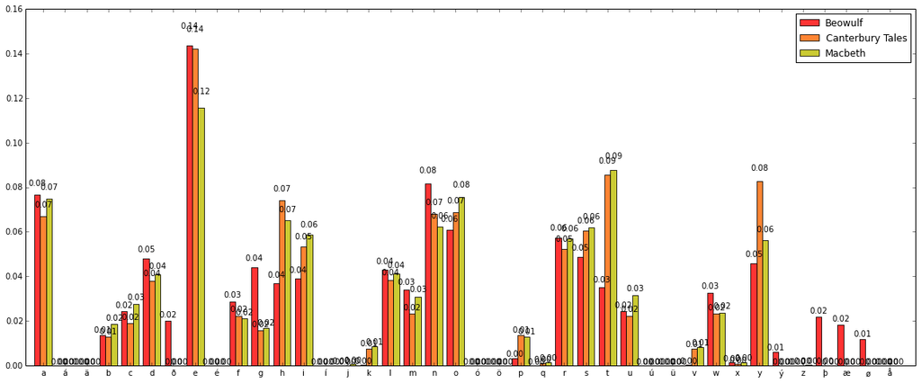

```
Distance between Beowulf and Canterbury Tales: 0.0937931062273
Distance between Canterbury Tales and Macbeth: 0.044067588793
Distance between Beowulf and Macbeth: 0.0910303106517
```

```python
letterPlot([beowulf_p,canterbury_p,macbeth_p],['r','#FF6600','y'],['Beowulf','Canterbury Tales', 'Macbeth'])
print "Distance between Beowulf and Canterbury Tales: " + str(distance(beowulf_p,canterbury_p))
print "Distance between Canterbury Tales and Macbeth: " + str(distance(canterbury_p,macbeth_p))
print "Distance between Beowulf and Macbeth: " + str(distance(beowulf_p,macbeth_p))
```

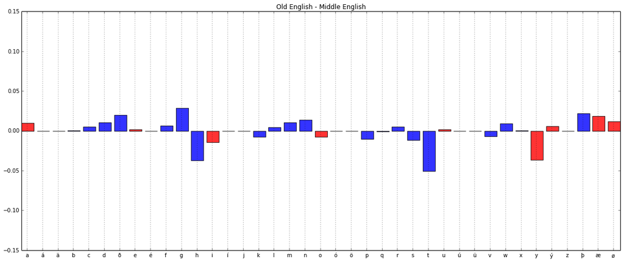

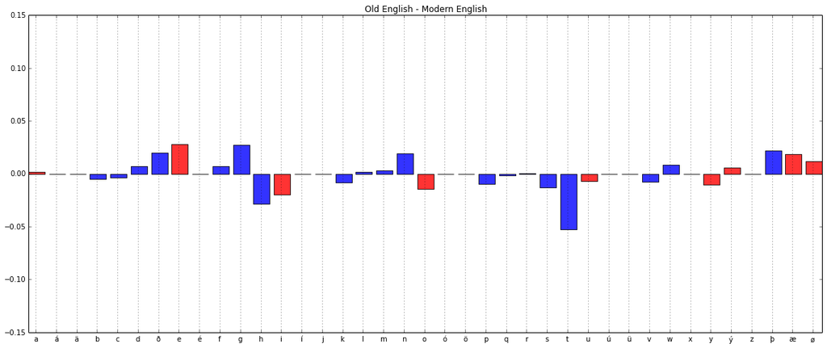

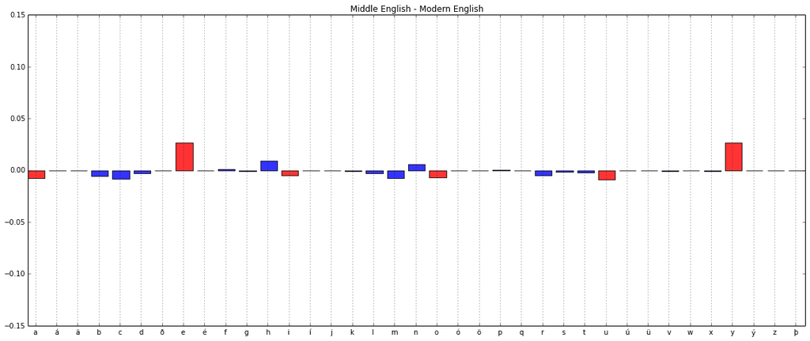

```python
differencePlot(beowulf_p,canterbury_p,'Old English','Middle English')
differencePlot(beowulf_p,macbeth_p,'Old English','Modern English')
differencePlot(canterbury_p,macbeth_p,'Middle English','Modern English')
```

Surprisingly, Beowulf is slightly closer to Macbeth than it is to Canterbury Tales, and Canterbury Tales is certainly much closer to Macbeth than Beowulf is to either. Part of this can be accounted for by the decline in characters such as ð, þ, æ, and ø in English. Some quick research indicates that this is also partly due to the [Norman Conquest of England](http://en.wikipedia.org/wiki/Norman_conquest_of_England), in which the Norman language (related to French) influenced Middle English.

There's also a significantly higher frequency of the letters H and T in Middle and Modern English than in Old English - this could be due to the digraph 'TH' (as in *THeta*) being represented by the letter thorn (þ), and its 'softer' equivalent, eth (ð).

Let's look at something slightly more recent:

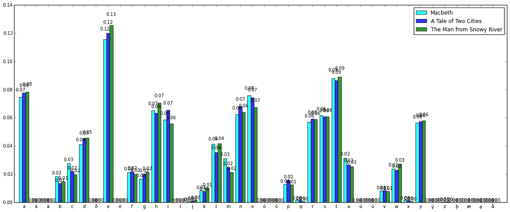

```
Distance between Macbeth and A Tale of Two Cities: 0.0179019089007
Distance between Macbeth and The Man from Snowy River: 0.0223210230498
Distance between A Tale of Two Cities and The Man from Snowy River: 0.0189063452769
```

```python
letterPlot([macbeth_p,taleOfTwo_p,snowy_p],['#00FFFF','b','g'],['Macbeth','A Tale of Two Cities','The Man from Snowy River'])
print "Distance between Macbeth and A Tale of Two Cities: " + str(distance(taleOfTwo_p,macbeth_p))
print "Distance between Macbeth and The Man from Snowy River: " + str(distance(macbeth_p,snowy_p))
print "Distance between A Tale of Two Cities and The Man from Snowy River: " + str(distance(taleOfTwo_p,snowy_p))
```

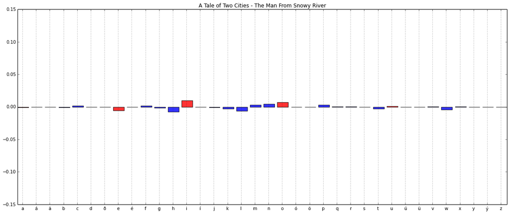

```python
differencePlot(taleOfTwo_p,snowy_p,'A Tale of Two Cities','The Man From Snowy River')
```

Interesting. It seems that Modern English seems to have converged on these rough values in the last few hundred years, with Macbeth being written sometime around early 17th Century, and Tale of Two Cities & Man from Snowy River both being written in the late 19th Century - one by an Englishman and the other by an Australian. In spite of this, they're all quite close, and no letter seems to stick out significantly on the graph.

Now that we've had a look at English, let's move up a level and compare some of the West Germanic languages.

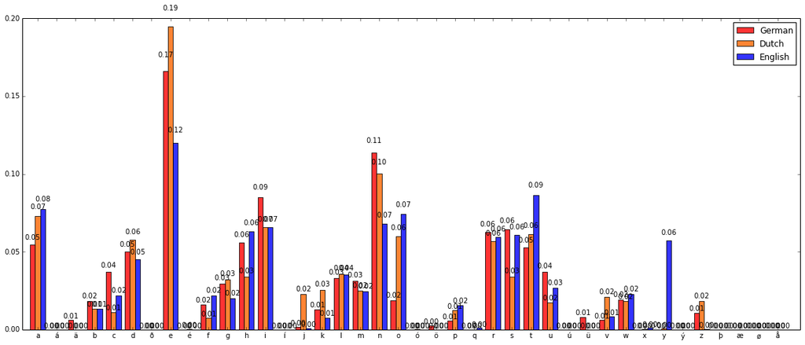

```
Distance between German and Dutch: 0.0851820563751
Distance between German and English: 0.116532471984
Distance between Dutch and English: 0.119189189497


Distance between German and Old English: 0.10850209465
Distance between Dutch and Old English: 0.105993865352
Distance between German and Middle English: 0.126572976285
Distance between Dutch and Middle English: 0.12662701417
```

```python
letterPlot([betrachtung_p,camera_p,taleOfTwo_p],['r','#FF6600','b'],['German','Dutch','English'])
print "Distance between German and Dutch: " + str(distance(betrachtung_p,camera_p))
print "Distance between German and English: " + str(distance(betrachtung_p,taleOfTwo_p))
print "Distance between Dutch and English: " + str(distance(camera_p,taleOfTwo_p))
print "\n"
print "Distance between German and Old English: " + str(distance(betrachtung_p,beowulf_p))
print "Distance between Dutch and Old English: " + str(distance(camera_p,beowulf_p))
print "Distance between German and Middle English: " + str(distance(betrachtung_p,canterbury_p))
print "Distance between Dutch and Middle English: " + str(distance(camera_p,canterbury_p))
```

In the graph above, we can certainly see some rough similarities, but also some pronounced differences - we can see that Dutch uses the letter J significantly more than German & English, and English uses Y much more than the others - this is due to the German & Dutch letter J being pronounced as Y, so using the letter Y would be largely redundant.